# STT 3851 Project 2 Final

Kassidy Borum, Adam Seagle, Jordan Greene

5/06/2020

# A: First Candidate Model

```r
#Final Model from Project 1
model1 <- lm(price ~ bedrooms + bath + garagesize + status +
                       elem + size + lot + bedrooms:bath, house)
summary(model1)
```

```
##
## Call:
## lm(formula = price ~ bedrooms + bath + garagesize + status +
##     elem + size + lot + bedrooms:bath, data = house)
##
## Residuals:
##    Min     1Q Median     3Q    Max
## -89.30 -23.67   2.11  25.03  95.96
##
## Coefficients:
##               Estimate Std. Error t value Pr(>|t|)
## (Intercept)    343.587    119.876   2.866  0.00567 **
## bedrooms       -80.626     33.128  -2.434  0.01784 *
## bath           -94.512     49.121  -1.924  0.05894 .
## garagesize       9.542      8.582   1.112  0.27049
## statuspen      -14.967     16.070  -0.931  0.35528
## statussld      -34.272     13.560  -2.528  0.01405 *
## elemcrest       11.877     33.399   0.356  0.72333
## elemedge        18.273     28.880   0.633  0.52924
## elemedison      92.979     29.437   3.159  0.00245 **
## elemharris      71.138     31.138   2.285  0.02577 *
## elemparker      12.543     31.620   0.397  0.69296
## size            68.339     29.972   2.280  0.02605 *
## lot              8.606      3.584   2.401  0.01937 *
## bedrooms:bath   29.609     14.030   2.110  0.03886 *
## ---
## Signif. codes:  0 '***' 0.001 '**' 0.01 '*' 0.05 '.' 0.1 ' ' 1
##
## Residual standard error: 43.52 on 62 degrees of freedom
## Multiple R-squared:  0.5699, Adjusted R-squared:  0.4797
## F-statistic:  6.32 on 13 and 62 DF,  p-value: 2.159e-07
```

# B: Second Candidate Model

```r
names(house)
```

```
##  [1] "id"              "price"           "size"            "lot"
##  [5] "bath"            "bedrooms"        "yearbuilt"       "agestandardized"
##  [9] "garagesize"      "status"          "elem"
```

```r
dim(house)
```

```
## [1] 76 11
```

```r
sum(is.na(house))
```

```
## [1] 0
```

```r
reg.fit.full <- regsubsets(price ~ ., data=house, method="forward", really.big = TRUE)
```

```
## Reordering variables and trying again:
```

```r
reg.summary <- summary(reg.fit.full)
reg.summary
```

```
## Subset selection object
## Call: regsubsets.formula(price ~ ., data = house, method = "forward",
##     really.big = TRUE)
## 15 Variables  (and intercept)
##                 Forced in Forced out
## id                  FALSE      FALSE
## size                FALSE      FALSE
## lot                 FALSE      FALSE
## bath                FALSE      FALSE
## bedrooms            FALSE      FALSE
## yearbuilt           FALSE      FALSE
## garagesize          FALSE      FALSE
## statuspen           FALSE      FALSE
## statussld           FALSE      FALSE
## elemcrest           FALSE      FALSE
## elemedge            FALSE      FALSE
## elemedison          FALSE      FALSE
## elemharris          FALSE      FALSE
## elemparker          FALSE      FALSE
## agestandardized     FALSE      FALSE
## 1 subsets of each size up to 9
## Selection Algorithm: forward
##          id  size lot bath bedrooms yearbuilt agestandardized garagesize
## 1  ( 1 ) " " " "  " " " "  " "      " "       " "             "*"
## 2  ( 1 ) " " " "  " " " "  " "      " "       " "             "*"
## 3  ( 1 ) " " " "  " " " "  " "      " "       " "             "*"
## 4  ( 1 ) " " " "  "*" " "  " "      " "       " "             "*"
## 5  ( 1 ) " " " "  "*" " "  " "      " "       " "             "*"
## 6  ( 1 ) " " "*"  "*" " "  " "      " "       " "             "*"
## 7  ( 1 ) " " "*"  "*" " "  "*"      " "       " "             "*"
## 8  ( 1 ) " " "*"  "*" " "  "*"      " "       " "             "*"
## 9  ( 1 ) " " "*"  "*" " "  "*"      " "       " "             "*"
##          statuspen statussld elemcrest elemedge elemedison elemharris
## 1  ( 1 ) " "       " "       " "       " "      " "        " "
## 2  ( 1 ) " "       " "       " "       " "      "*"        " "
## 3  ( 1 ) " "       " "       " "       " "      "*"        "*"
## 4  ( 1 ) " "       " "       " "       " "      "*"        "*"
## 5  ( 1 ) " "       "*"       " "       " "      "*"        "*"
## 6  ( 1 ) " "       "*"       " "       " "      "*"        "*"
## 7  ( 1 ) " "       "*"       " "       " "      "*"        "*"
## 8  ( 1 ) " "       "*"       " "       " "      "*"        "*"
## 9  ( 1 ) "*"       "*"       " "       " "      "*"        "*"
##          elemparker
## 1  ( 1 ) " "
## 2  ( 1 ) " "
## 3  ( 1 ) " "
## 4  ( 1 ) " "
## 5  ( 1 ) " "
## 6  ( 1 ) " "
## 7  ( 1 ) " "
## 8  ( 1 ) "*"
## 9  ( 1 ) "*"
```

```r
names(reg.summary)
```

```
## [1] "which"  "rsq"    "rss"    "adjr2"  "cp"     "bic"    "outmat" "obj"
```

- Based on the summary of the full regfit model, the best predictors are `lot`, `garagesize`, `elemedison`, and `elemharris`

```r
reg.summary$rsq
```

```
## [1] 0.1284406 0.2640426 0.3486598 0.4198205 0.4545951 0.4981174 0.5131764
## [8] 0.5254678 0.5360825
```

- You can see the $R^2$ value increases from 12.84% with one variable to 53.61% when we use all the variables.

```r
reg.summary$bic
```

```
## [1]  -1.786348 -10.308111 -15.260032 -19.722081 -20.088837 -22.078434 -20.062997
## [8] -17.675759 -15.064350
```

```r
par(mfrow=c(2,2))
plot(reg.summary$rsq, xlab = "Number of Variables", ylab = "R-squared",type="l")
which.max(reg.summary$rsq)
```

```
## [1] 9
```

```r
plot(reg.summary$adjr2, xlab = "Number of Variables", ylab = "Adjusted R-squared",type="l")
which.max(reg.summary$adjr2)
```

```
## [1] 9
```

```r
points(9, reg.summary$adjr2[9], col = "green", cex = 2, pch = 20)

plot(reg.summary$cp, xlab = "Number of Variables", ylab = "Cp", type = "l")
which.min(reg.summary$cp)
```

```
## [1] 6
```

```r
points(6, reg.summary$cp[6], col = "purple", cex = 2, pch = 20)
which.min(reg.summary$bic)
```

```
## [1] 6
```

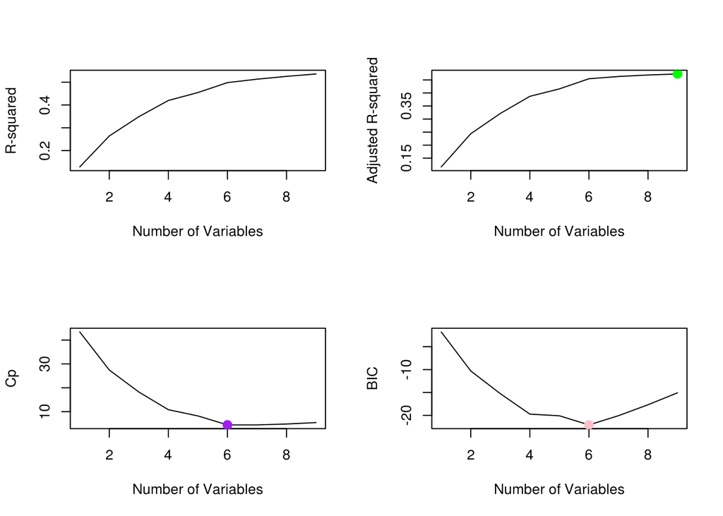

```r
plot(reg.summary$bic, xlab = "Number of Variables", ylab = "BIC", type = "l")

points(6, reg.summary$bic[6], col = "pink", cex = 2, pch = 20)
```

- The Adjust $R^2$ is shows that 9 predictors is the best.

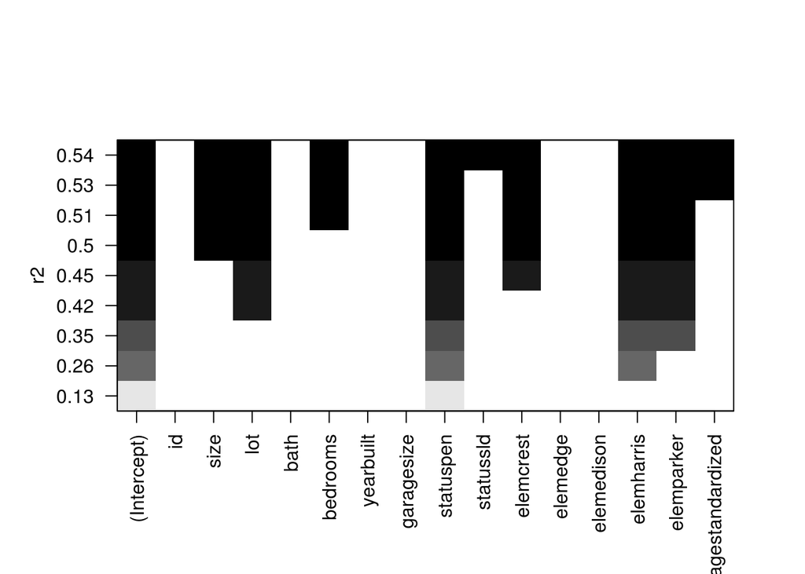

```r
#view(house)
plot(reg.fit.full,scale="r2")
```

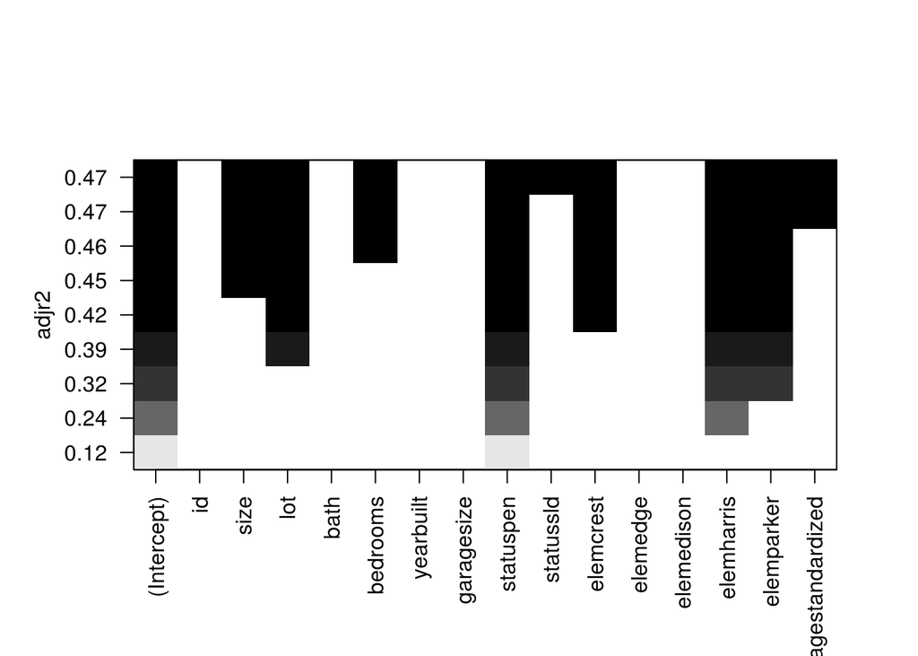

```r
plot(reg.fit.full,scale="adjr2")
```

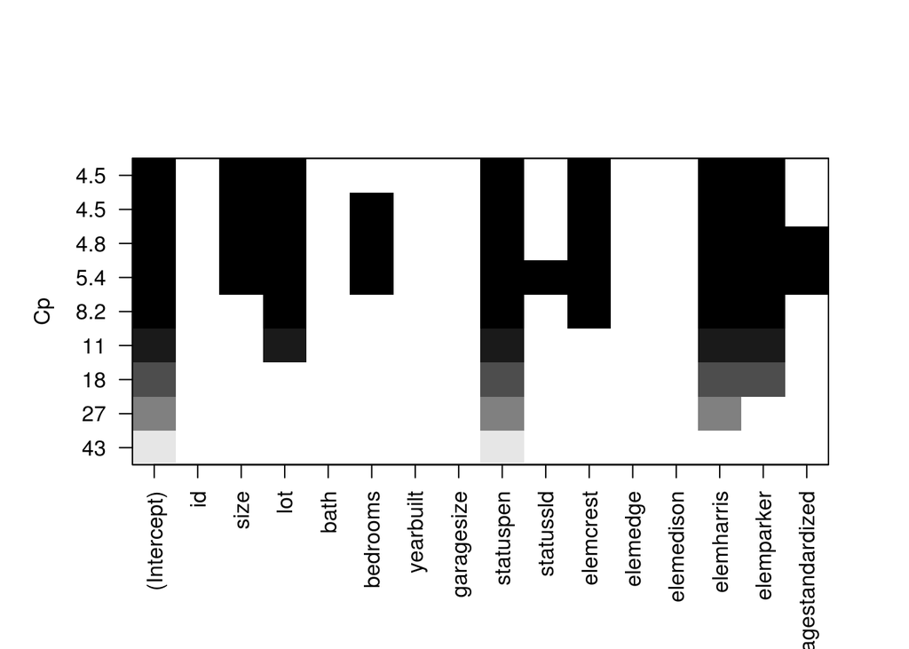

```r
plot(reg.fit.full,scale="Cp")
```

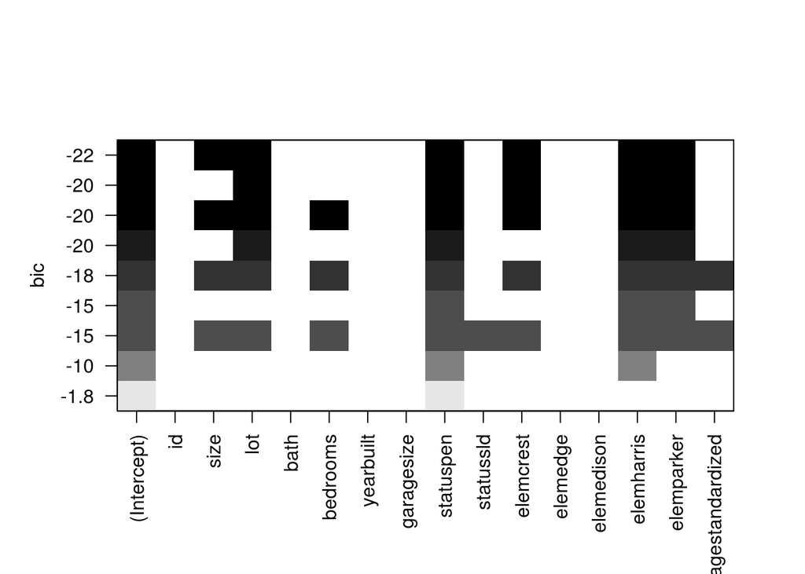

```r
plot(reg.fit.full,scale="bic")
```

```r
coef(reg.fit.full, 9)
```

```
##     (Intercept)            size             lot        bedrooms       statuspen
##      147.626260       91.846401       10.204999      -16.731854      -16.123815
##       statussld       elemcrest      elemharris      elemparker agestandardized
##      -38.744904      -26.995488       33.262206      -39.826355       -3.133348
```

- The significant coeffcients are `size`, `lot`, `bedrooms`, `status`, and `elementary`.

## Model Summary

```r
model2 <- lm(price ~ size + lot + bedrooms + garagesize + status + elem, data = house)
summary(model2)
```

```
##
## Call:
## lm(formula = price ~ size + lot + bedrooms + garagesize + status +
##     elem, data = house)
##
## Residuals:
##     Min      1Q  Median      3Q     Max
## -91.638 -29.448  -1.418  26.074 105.480
##
## Coefficients:
##             Estimate Std. Error t value Pr(>|t|)
## (Intercept)  114.474     54.760   2.090  0.04055 *
## size          80.711     27.633   2.921  0.00482 **
## lot           10.047      3.532   2.845  0.00596 **
## bedrooms     -12.405      8.564  -1.449  0.15235
## garagesize     9.633      8.685   1.109  0.27149
## statuspen    -19.833     16.211  -1.223  0.22566
## statussld    -37.997     13.723  -2.769  0.00735 **
## elemcrest      1.698     33.706   0.050  0.95998
## elemedge       6.138     28.572   0.215  0.83059
## elemedison    82.385     29.561   2.787  0.00700 **
## elemharris    53.632     29.951   1.791  0.07808 .
## elemparker   -14.254     29.637  -0.481  0.63220
## ---
## Signif. codes:  0 '***' 0.001 '**' 0.01 '*' 0.05 '.' 0.1 ' ' 1
##
## Residual standard error: 44.46 on 64 degrees of freedom
## Multiple R-squared:  0.5366, Adjusted R-squared:  0.457
## F-statistic: 6.738 on 11 and 64 DF,  p-value: 2.292e-07
```

- This model has a slightly smaller adjust R-squared value (0.457) in comparison to our intial model from project 1 (.4797)
  - `status` and `elem` have different cateogrical values:
    - `status`: statuspen, statussld,
    - `elem`: elemcrest, elemedge, elemedison, elemharris, elemparker
  - only statussld and elemedison are seen to be statically significant, while elemharris is slightly above the desire p-value of 0.05.

# C: Train/Test Split

```r
set.seed(1)
index <- sample(nrow(house), nrow(house) * 0.50, replace = FALSE)

train <- house[index,]
test <- house[-index,]
```

# D: Third Candidate Model

```r
reg.best <- regsubsets(price ~ size + lot + bath + bedrooms + agestandardized + garagesize + status + elem, data = train, nvmax = 13)
test.matrix <- model.matrix(price ~ size + lot + bath + bedrooms + agestandardized + garagesize + status + elem, data=test, nvmax = 13)


valid.errors <- rep(NA, 13)

i = 0
for(i in 1:13){
  coef.reg=coef(reg.best,id=i)
  pred=test.matrix[,names(coef.reg)]%*%coef.reg
  valid.errors[i] <- mean((test$price-pred)^2)
}

valid.errors
```

```
##  [1] 4549.240 4386.555 3309.531 3000.454 3077.233 2696.617 2809.005 2991.317
##  [9] 2848.223 2887.836 2913.754 2918.906 2920.493
```

```r
which.min(valid.errors) #Which model with the smallest error
```

```
## [1] 6
```

```r
reg.best <- regsubsets(price ~ size + lot + bath + bedrooms + agestandardized + garagesize + status + elem, data = house)
coef(reg.best,which.min(valid.errors))
```

```
## (Intercept)        size         lot    bedrooms   statussld  elemedison
##  127.556047   85.475310    9.995031  -16.004639  -34.907872   79.665432
##  elemharris
##   54.392695
```

```r
model3 <- lm(price ~ size + lot + bedrooms + status + elem, data = house)
summary(model3)
```

```
##
## Call:
## lm(formula = price ~ size + lot + bedrooms + status + elem, data = house)
##
## Residuals:
##     Min      1Q  Median      3Q     Max
## -91.369 -29.241  -0.705  24.313 113.296
##
## Coefficients:
##             Estimate Std. Error t value Pr(>|t|)
## (Intercept)  118.460     54.739   2.164  0.03414 *
## size          90.210     26.319   3.428  0.00106 **
## lot           10.754      3.480   3.091  0.00294 **
## bedrooms     -15.786      8.018  -1.969  0.05324 .
## statuspen    -20.543     16.227  -1.266  0.21004
## statussld    -43.291     12.890  -3.359  0.00131 **
## elemcrest      1.261     33.763   0.037  0.97033
## elemedge      11.903     28.145   0.423  0.67376
## elemedison    85.616     29.470   2.905  0.00501 **
## elemharris    58.506     29.680   1.971  0.05296 .
## elemparker   -11.034     29.546  -0.373  0.71004
## ---
## Signif. codes:  0 '***' 0.001 '**' 0.01 '*' 0.05 '.' 0.1 ' ' 1
##
## Residual standard error: 44.54 on 65 degrees of freedom
## Multiple R-squared:  0.5277, Adjusted R-squared:  0.4551
## F-statistic: 7.263 on 10 and 65 DF,  p-value: 1.393e-07
```

- This model has a good multiple r-squared value of 0.5277 and F-statistic, 7.263. But the adjusted r-squared value is smaller than the model from the previous part and from project 1.

# E: Ridge Regression

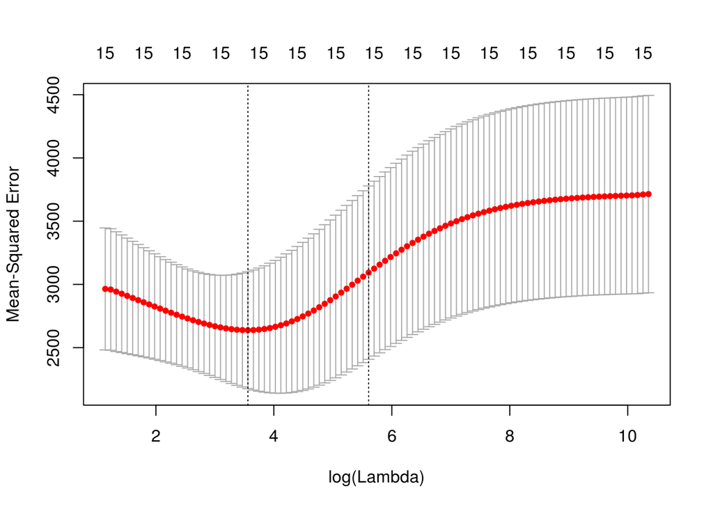

```r
train.x = model.matrix(price ~ ., train)
train.y = train$price
test.x = model.matrix(price ~ ., test)
test.y = test$price

set.seed(1)

cv.out = cv.glmnet(train.x, train.y, alpha = 0)
plot(cv.out)
```

```r
bestlam = cv.out$lambda.min
bestlam
```

```
## [1] 35.17193
```

```r
RidgeModel <- glmnet(train.x, train.y, alpha = 0, lambda = bestlam, thresh = 1e-12)
coef(RidgeModel)
```

```
## 17 x 1 sparse Matrix of class "dgCMatrix"
##                           s0
## (Intercept)     378.86984771
## (Intercept)       .
## id                0.04033092
## size             41.24714845
## lot               9.55732538
## bath              2.69116842
## bedrooms        -10.26168595
## yearbuilt        -0.09701842
## agestandardized  -0.97018232
## garagesize        5.72651424
## statuspen         0.31937912
## statussld       -17.77670673
## elemcrest        12.20030265
## elemedge         -5.38812763
## elemedison       35.75395896
## elemharris       33.63075991
## elemparker      -21.34005018
```

```r
model4 <- RidgeModel
```

# F: Principal Components Regression/Partial Least Squares Regression

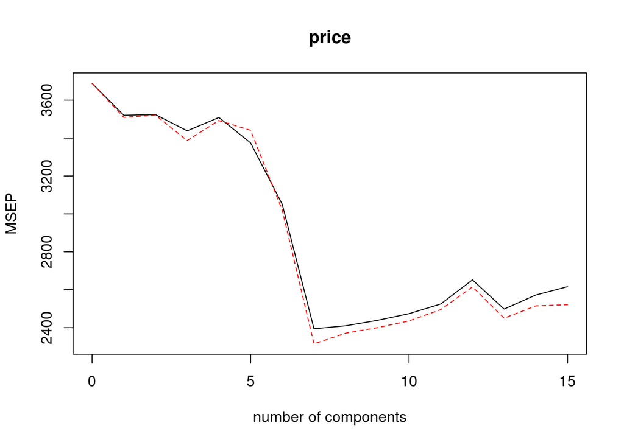

```r
set.seed(1)
pcr.fit=pcr(price ~ ., data=house,scale=TRUE,validation="CV")
pcr.min <- which.min(RMSEP(pcr.fit)$val[1,,]) - 1
validationplot(pcr.fit,val.type="MSEP")
```

```r
set.seed(1)
pls.fit=plsr(price ~ ., data=house,subset = index ,scale=TRUE, validation="CV")
summary(pls.fit)
```

[output not shown]

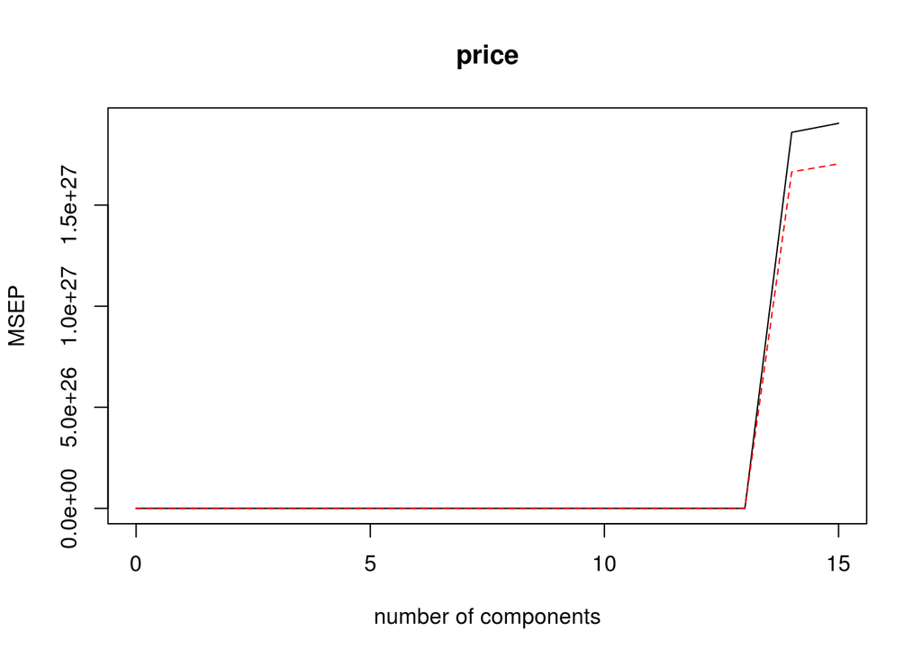

```r
validationplot(pls.fit,val.type="MSEP")
```

- After comparing both PLS and PCR we choose the PCR model. The PCR cross validation error is minimized at 7 components as shown in the plot. This model had slightly better overall comparative values versus the PLS model.

# G: Errors and Comparisons

```r
Pred1 <- predict(model1, test)
Error1 <- mean((Pred1-test.y)^2)

Pred2 <- predict(model2, test)
Error2 <- mean((Pred2 - test.y)^2)

Pred3 <- predict(model3, test)
Error3 <- mean((Pred3 - test.y)^2)

Pred4 = predict(model4, s = bestlam, newx = test.x)
Error4 <- mean((Pred4-test.y)^2)

# We were stating PCR number of components, yet using the PLS model
# Pred5 = predict(pls.fit, test, ncomp = 1)
# Error5 <- mean((Pred5-test.y)^2)

Pred5 = predict(pcr.fit, test, ncomp = 7)
Error5 <- mean((Pred5-test.y)^2)

cbind(Error1, Error2, Error3, Error4, Error5)
```

```
##       Error1   Error2   Error3   Error4   Error5
## [1,] 1832.57 2068.742 2197.164 2574.623 2085.447
```

```r
rsq = function (predicted, actual) {
  return(1 - (sum((predicted - actual) ^ 2)/sum((actual - mean(actual)) ^ 2) ))
}

RSQ1 <- rsq(Pred1, test.y)

RSQ2  <- rsq(Pred2, test.y)

RSQ3  <- rsq(Pred3, test.y)

RSQ4 <- rsq(Pred4, test.y)

RSQ5  <- rsq(Pred5, test.y)
cbind(RSQ1, RSQ2, RSQ3, RSQ4, RSQ5)
```

```
##           RSQ1      RSQ2      RSQ3      RSQ4      RSQ5
## [1,] 0.4632854 0.3941165 0.3565049 0.2459565 0.3892241
```

- Based on the errors, we can rank our canidate models as follow(smaller to larger error vlaues):
  1. Model 1 / Inital Model = 1832.57
  2. Model 2 / Regsub Model over all data = 2068.742
  3. Model 5 / PCR Regression = 2085.447
  4. Model 3 / Regsub Model over training data = 2197.164
  5. Model 4 / Ridge Regression = 2574.623
- We can rank the models based on their $R^2$ values as follows:
  1. Model 1 / Initial Model = 46.33
  2. Model 2 / Regsub Model over all data = 39.41
  3. Model 5 / PCR Regression = 38.92
  4. Model 3 / Regsub Model over training data = 35.65
  5. Model 4 / Ridge Regression = 24.60

# Final Model Presentation

- We decided to stick with our inital model, the final model from Project 1 as our final model for Project 2 based on it having the lowest MSE and highest $R^2$ value computed above.

```r
FinalModel <- lm(price ~ bedrooms + bath + garagesize + status +
                       elem + size + lot + bedrooms:bath, house)
summary(FinalModel)
```

```
##
## Call:
## lm(formula = price ~ bedrooms + bath + garagesize + status +
##     elem + size + lot + bedrooms:bath, data = house)
##
## Residuals:
##    Min     1Q Median     3Q    Max
## -89.30 -23.67   2.11  25.03  95.96
##
## Coefficients:
##               Estimate Std. Error t value Pr(>|t|)
## (Intercept)    343.587    119.876   2.866  0.00567 **
## bedrooms       -80.626     33.128  -2.434  0.01784 *
## bath           -94.512     49.121  -1.924  0.05894 .
## garagesize       9.542      8.582   1.112  0.27049
## statuspen      -14.967     16.070  -0.931  0.35528
## statussld      -34.272     13.560  -2.528  0.01405 *
## elemcrest       11.877     33.399   0.356  0.72333
## elemedge        18.273     28.880   0.633  0.52924
## elemedison      92.979     29.437   3.159  0.00245 **
## elemharris      71.138     31.138   2.285  0.02577 *
## elemparker      12.543     31.620   0.397  0.69296
## size            68.339     29.972   2.280  0.02605 *
## lot              8.606      3.584   2.401  0.01937 *
## bedrooms:bath   29.609     14.030   2.110  0.03886 *
## ---
## Signif. codes:  0 '***' 0.001 '**' 0.01 '*' 0.05 '.' 0.1 ' ' 1
##
## Residual standard error: 43.52 on 62 degrees of freedom
## Multiple R-squared:  0.5699, Adjusted R-squared:  0.4797
## F-statistic:  6.32 on 13 and 62 DF,  p-value: 2.159e-07
```

- This final model accounts for aproximately 57% of the variation and the lowest MSE (1832.57).
- Model 2 is a good runner up model, the multiple r-sqaured value slightly descreases in comparison to model1 / Final Model, but the f-statistic slightly increases.

```r
summary(model2)
```

```
##
## Call:
## lm(formula = price ~ size + lot + bedrooms + garagesize + status +
##     elem, data = house)
##
## Residuals:
##     Min      1Q  Median      3Q     Max
## -91.638 -29.448  -1.418  26.074 105.480
##
## Coefficients:
##             Estimate Std. Error t value Pr(>|t|)
## (Intercept)  114.474     54.760   2.090  0.04055 *
## size          80.711     27.633   2.921  0.00482 **
## lot           10.047      3.532   2.845  0.00596 **
## bedrooms     -12.405      8.564  -1.449  0.15235
## garagesize     9.633      8.685   1.109  0.27149
## statuspen    -19.833     16.211  -1.223  0.22566
## statussld    -37.997     13.723  -2.769  0.00735 **
## elemcrest      1.698     33.706   0.050  0.95998
## elemedge       6.138     28.572   0.215  0.83059
## elemedison    82.385     29.561   2.787  0.00700 **
## elemharris    53.632     29.951   1.791  0.07808 .
## elemparker   -14.254     29.637  -0.481  0.63220
## ---
## Signif. codes:  0 '***' 0.001 '**' 0.01 '*' 0.05 '.' 0.1 ' ' 1
##
## Residual standard error: 44.46 on 64 degrees of freedom
## Multiple R-squared:  0.5366, Adjusted R-squared:  0.457
## F-statistic: 6.738 on 11 and 64 DF,  p-value: 2.292e-07
```